# Integrating multi-omics underlying Down syndrome with OmicsPLS

# Apply OmicsPLS to methylation and glycomics

## Fit O2PLS

We fit O2PLS to the methylation and glycomics data, and calculate the variance explained by the joint and specific parts.

```r
fit <- o2m(methylation, glycomics, r, rx, ry)
summary(fit)
##
## *** Summary of the O2PLS fit ***
##
## -  Call: o2m(X = methylation, Y = glycomics, n = r, nx = rx, ny = ry)
##
## -  Modeled variation
## -- Total variation:
## in X: 377.2632
## in Y: 73.11544
##
## -- Joint, Orthogonal and Noise as proportions:
##
##            data X data Y
## Joint       0.100  0.097
## Orthogonal  0.135  0.903
## Noise       0.766  0.000
##
## -- Predictable variation in Y-joint part by X-joint part:
## Variation in T*B_T relative to U: 0.47
## -- Predictable variation in X-joint part by Y-joint part:
## Variation in U*B_U relative to T: 0.461
##
## -- Variances per component:
##
##         Comp 1 Comp 2 Comp 3 Comp 4
## X joint  9.298 11.867  8.038  8.409
## Y joint  4.678  1.132  1.156  0.117
##
##        Comp 1 Comp 2
## X Orth 30.302 20.611
##
##        Comp 1 Comp 2 Comp 3 Comp 4 Comp 5 Comp 6
## Y Orth 17.435 12.994  11.12  4.812 10.109 10.584
##
##
## -  Coefficient in 'U = T B_T + H_U' model:
## -- Diagonal elements of B_T =
##  0.488 0.219 0.28 0.076
```

## Visualize the results: loadings

Next, we inspect the loadings. Each of the 3322 loading values in the methylation parts represents a CpG site indicated by a cg ID. For the glycomics parts, we have 10 glycan peaks/IDs.

Each label is a cg ID or glycan ID, and the axes represent the respective components.

Give an interpretation of these results. Which features have highest loadings, in which components? Which glycan and methylation features have the highest covariance according to the plot? Click “zoom” in RStudio if the labels don’t fit on the screen.

*Answers (Click here)*

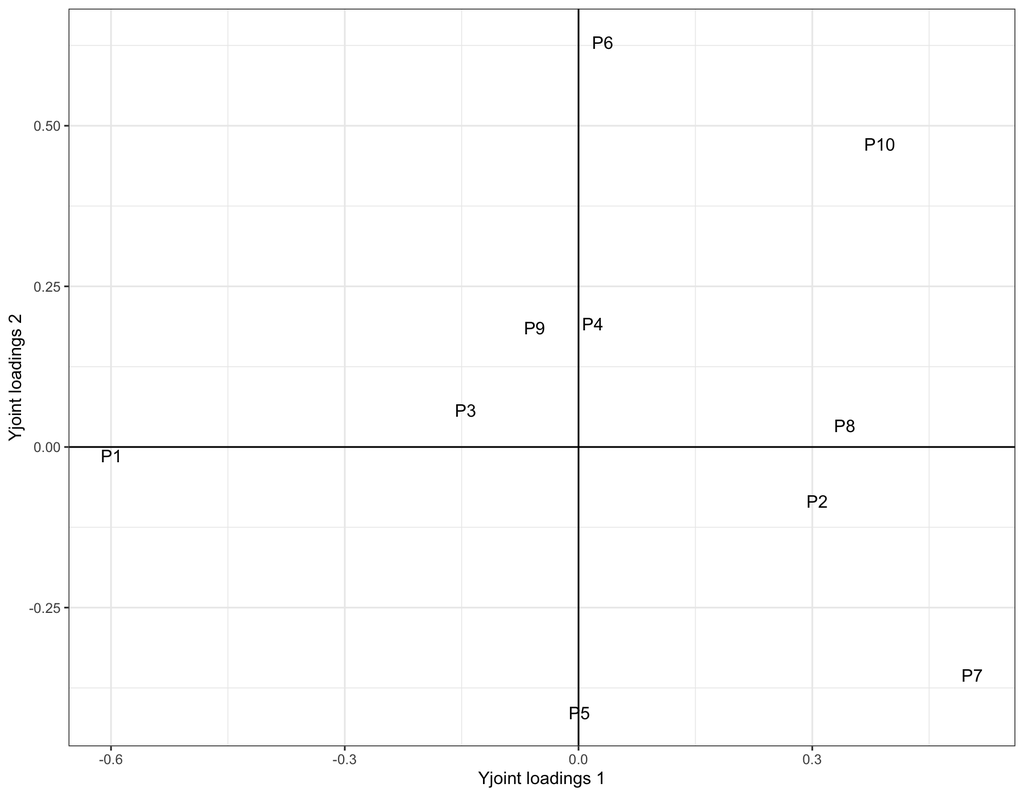

```r
plot(fit,loading_name = "Yj",i=1,j=2,label = "col") + theme_bw()
```

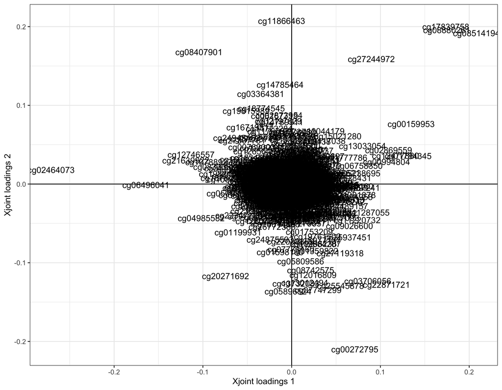

```r
plot(fit,loading_name = "Xj",i=1,j=2,label = "col") + theme_bw()
```

## Visualize the results: scores

Next, we investigate if these joint components are associated with Down syndrome. We first look at the scatterplot of the scores, colored by DS.

Give an interpretation. Are the joint scores able to separate Down syndrome?

*Answers (Click here)*

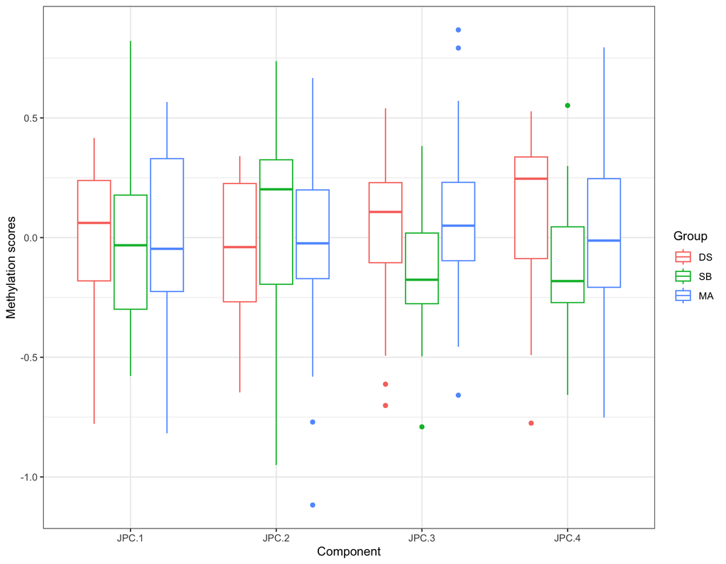

```r
data.frame(Group = ClinicalVars$group, JPC = scores(fit, "Xjoint")) %>%
  pivot_longer(-Group,
               names_to = "Comp",
               values_to = "Scores") %>%
  ggplot(aes(x=Comp, y=Scores, col=Group)) +
  geom_boxplot() + xlab("Component") + ylab("Methylation scores") +
  theme_bw()
```

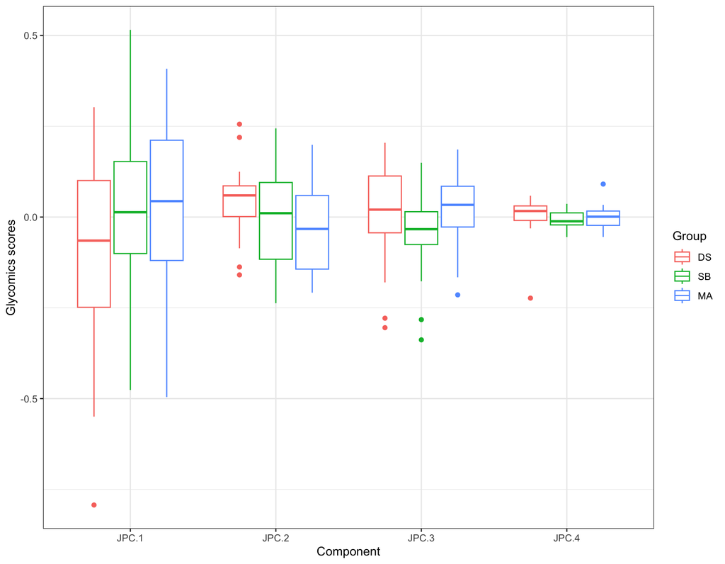

```r
data.frame(Group = ClinicalVars$group, JPC = scores(fit, "Yjoint")) %>%
  pivot_longer(-Group,
               names_to = "Comp",
               values_to = "Scores") %>%
  ggplot(aes(x=Comp, y=Scores, col=Group)) +
  geom_boxplot() + xlab("Component") + ylab("Glycomics scores") +
  theme_bw()
```

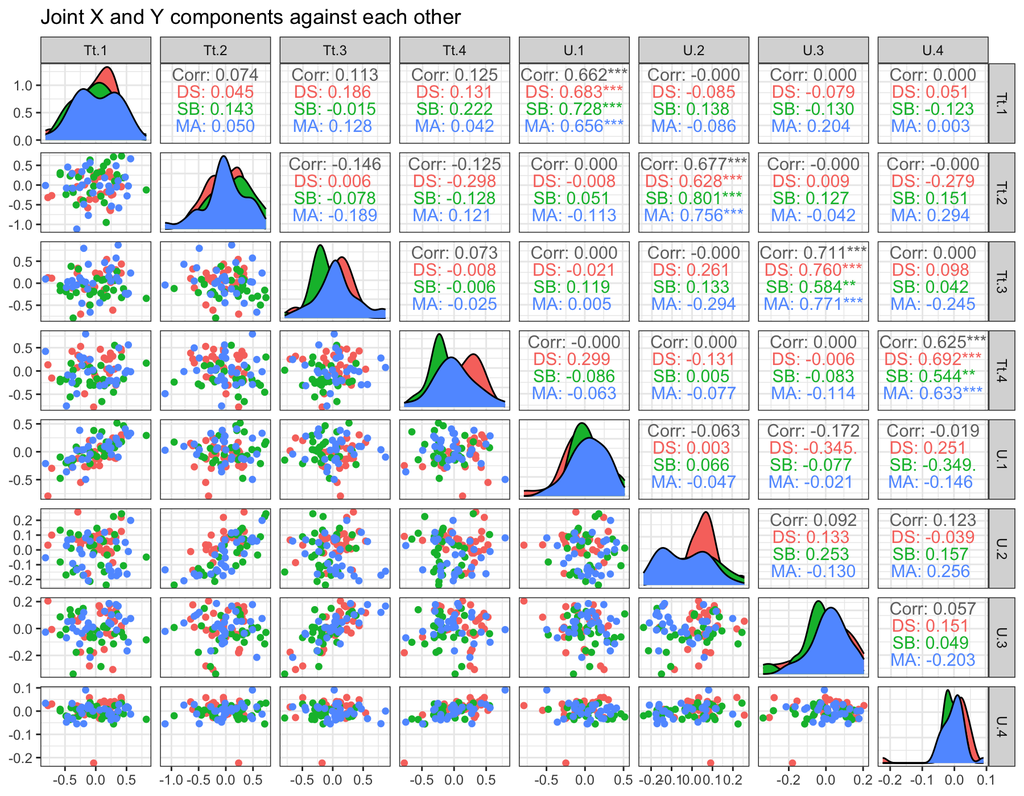

```r
## Another (fancy) approach is to run the following for multiple plots in one go
GGally::ggpairs(data.frame(Tt=fit$Tt,U=fit$U),
                aes(col = ClinicalVars$group), progress = FALSE,
                title = "Joint X and Y components against each other") + theme_bw()
## Registered S3 method overwritten by 'GGally':
##   method from
##   +.gg   ggplot2
```

We perform a logistic regression with the Down syndrome status as outcome, and the joint methylation scores as covariates. We exclude the mothers for now.

Which group category is the reference? Are there joint scores that are significantly associated with Down syndrome? Are the p-values correctly interpretable in this case? Why (not)?

*Answers (Click here)*

```r
glm_datmat <- data.frame(JPC=scores(fit, "Xjoint"),
           outc = ClinicalVars$group, age=ClinicalVars$age, sex=ClinicalVars$sex)
glm(outc ~ ., data = glm_datmat%>% filter(outc != "MA"), family = "binomial") %>%
  summary()
##
## Call:
## glm(formula = outc ~ ., family = "binomial", data = glm_datmat %>%
##     filter(outc != "MA"))
##
## Coefficients:
##             Estimate Std. Error z value Pr(>|z|)
## (Intercept) -1.33586    1.28203  -1.042   0.2974
## JPC.1       -1.00705    1.24328  -0.810   0.4179
## JPC.2        0.78268    1.04571   0.748   0.4542
## JPC.3       -2.20276    1.28321  -1.717   0.0861 .
## JPC.4       -2.30158    1.29227  -1.781   0.0749 .
## age          0.06824    0.04661   1.464   0.1431
## sexM        -1.78908    0.74301  -2.408   0.0160 *
## ---
## Signif. codes:  0 '***' 0.001 '**' 0.01 '*' 0.05 '.' 0.1 ' ' 1
##
## (Dispersion parameter for binomial family taken to be 1)
##
##     Null deviance: 77.561  on 55  degrees of freedom
## Residual deviance: 53.311  on 49  degrees of freedom
## AIC: 67.311
##
## Number of Fisher Scoring iterations: 5
```

# Interpretation of the top genes

Although determining a threshold to select the number of ‘top’ CpG sites is not straightforward, we are going to select 200 based on earlier analysis of these data. We also need to map from cg ID to gene ID.

```r
top_cg <- order(loadings(fit, subset=1)^2,decreasing = TRUE)
gene_list <- CpG_groups[top_cg[1:200]]
gene_list %<>% paste0(collapse = ";") %>%
  str_split(";") %>% unlist %>% unique
```

## Using string-DB

Copy-paste the top genes in the String-DB website.

Is there any remarkable clustering visible? Go to the analysis tab, is there any significant enrichment?

*Answers (Click here)*

```r
# gene_list %>% cat(sep="\n")
```

## Using DisGeNet

You can also use the DisGeNet R package to perform Disease-gene enrichment. If you cannot install the package, the output is given below.

Which disease clusters are most significant? What does this say about the top genes based on integrating methylation and glycomics data?

*Answers (Click here)*

```r
### Bonus, run this code to perform DisGeNet enrichment
# disgenet_api_key <- "271e054761763b144a97872b059fd573186bdd9f"
options(timeout=4e9)
httr::timeout(4e9) # if needed to give curl more time
DGN_DE <- disgenet2r::disease_enrichment(gene_list, database = "ALL")
DGN_DE@qresult[1:10,
          c("Description", "FDR", "Ratio",  "BgRatio")]
## <request>
## Options:
## * timeout_ms: 4e+12
##                             Description          FDR Ratio   BgRatio
## 246                       Down Syndrome 2.853062e-42 45/76 766/21666
## 2750       Complete Trisomy 21 Syndrome 6.387882e-42 43/76 669/21666
## 2335      DOWN SYNDROME CRITICAL REGION 7.825305e-20 14/76  57/21666
## 1831             Chromosome 21 monosomy 6.913355e-05  4/76  13/21666
## 1591  Down Syndrome, Partial Trisomy 21 2.107633e-04  4/76  19/21666
## 1592 Trisomy 21, Meiotic Nondisjunction 2.107633e-04  4/76  19/21666
## 1782 Trisomy 21, Mitotic Nondisjunction 2.107633e-04  4/76  19/21666
## 394                Hirschsprung Disease 3.262582e-04 10/76 384/21666
## 1812       Unverricht-Lundborg Syndrome 4.863252e-04  5/76  56/21666
## 181                 Cognition Disorders 2.384353e-03 11/76 607/21666
```

```
                       Description          FDR Ratio   BgRatio
236                  Down Syndrome 4.983930e-35 38/65 766/21666
2736  Complete Trisomy 21 Syndrome 2.709284e-34 36/65 669/21666
2320 DOWN SYNDROME CRITICAL REGION 9.293346e-19 13/65  57/21666
1853        Chromosome 21 monosomy 1.849628e-07  5/65  13/21666
2468      Alzheimer disease type 1 1.452115e-05  3/65   3/21666
169            Cognition Disorders 8.819130e-05 12/65 607/21666
375           Hirschsprung Disease 8.819130e-05 10/65 384/21666
548             Mental Retardation 1.006005e-04 11/65 505/21666
207             Presenile dementia 2.703029e-03 11/65 718/21666
303             Fragile X Syndrome 4.152165e-03  6/65 194/21666
```

BONUS: You can also combine the String-DB and DisGeNet analyses by making an interaction netwerk of the genes in a particular disease term. Below is the code to print the genes that are in the Down Syndrome disease term. This list can be copy-pasted into String-DB and analyzed.

```r
DGN_DownS <- DGN_DE@qresult %>%
    filter(Description == "Down Syndrome") %>%
    pull(shared_symbol) %>% str_split(";") %>% unlist
# cat(DGN_DownS, sep="\n")
```